# HW7_Wei_Yanran

# Problem 2: Sums of Squares

Four methods are used in calculating sums of squares. These methods are loop, vector operations, dopar and parSapply methods. The time for running these methods are displayed in the table below.The dataset is 1e+06 data selected from normal distribution with mean of 1 and standard deviation of 1. I shrink the dataset from 1e+7 to 1e+6 because my computer will get stuck when running parSapply method.

Time for Different Methods

|  | user.self | sys.self | elapsed | Sum of Squares |
| --- | --- | --- | --- | --- |
| **Loop_Method** | 0.14 | 0 | 0.14 | 1002631 |
| **Vector_Method** | 0.08 | 0 | 0.08 | 1002631 |
| **Dopar_Method** | 0.03 | 0.08 | 0.37 | 1002631 |
| **ParSapply_Method** | 1.54 | 0.57 | 3.78 | 1002631 |

# Problem 3

Running time for GD and Linear Methods

|  | user.self | sys.self | elapsed | user.child | sys.child |
| --- | --- | --- | --- | --- | --- |
| **GD_time** | 0.29 | 0 | 1.09 | NA | NA |
| **Linear_Time** | 0 | 0 | 0 | NA | NA |

Coefficients of GD Method

|  | Tolerance | theta1 | theta2 |
| --- | --- | --- | --- |
| **result.1** | 1 | 1 | 2 |
| **result.2** | 0.1 | 1 | 2 |
| **result.3** | 0.01 | 1 | 2 |
| **result.4** | 0.001 | 1 | 2 |
| **result.5** | 1e-04 | 0.9999 | 2 |
| **result.6** | 1e-05 | 0.9993 | 1.998 |
| **result.7** | 1e-06 | 0.9743 | 2.001 |
| **result.8** | 1e-07 | 0.97 | 2.001 |
| **result.9** | 1e-08 | 0.9696 | 2.002 |
| **result.10** | 1e-09 | 0.9696 | 2.002 |

Coefficients of Linear Regression Methods

|  | X1 | X2 |
| --- | --- | --- |
| **lm_h.coefficients** | 0.9696 | 2.002 |

In the parallelize method, cluster 2 was used. The parameter I made adjustment on is tolerance. As shown in the table *Coefficients of GD Method*, as tolerance becoming smaller, the coefficients becomes more accurate. When tolerance is less or equal than 1e-08, we get the same coefficients with that calculated by linear regression.But gradient descent method seems take more time than linear regression method.

# problem 4

## a

Dopar function was used to bootstrop 10000 samples from Y and X. Each sample contains 10 parwise data and is chosen from the 200 pairwise dataset of X and Y. Linear regression model was built to test the relationship between x and y and to get the coefficients of the regression line.Cluster 2 was utilized.

## b

Overview of Beta

|  | x1 | x2 | x3 | x4 |
| --- | --- | --- | --- | --- |
| **result.1** | 1.171 | 2.408 | 2.877 | -0.01823 |
| **result.2** | 0.8545 | 0.4641 | 3.446 | 4.015 |
| **result.3** | 2.571 | 1.532 | 2.938 | 0.06638 |
| **result.4** | 0.7621 | 1.986 | 1.913 | 0.0002426 |
| **result.5** | 1.581 | 3.514 | 3.078 | 0.5484 |
| **result.6** | 1.755 | 2.256 | 2.971 | -0.2122 |

Summary of Beta

| x1 | x2 | x3 | x4 |
| --- | --- | --- | --- |
| Min. :-3.1546 | Min. :-4.709 | Min. :-0.01366 | Min. :-5.290588 |
| 1st Qu.: 0.5148 | 1st Qu.: 1.731 | 1st Qu.: 2.76470 | 1st Qu.:-0.156978 |
| Median : 1.2360 | Median : 1.975 | Median : 2.97035 | Median : 0.001342 |
| Mean : 1.2201 | Mean : 1.953 | Mean : 2.91716 | Mean : 0.021566 |
| 3rd Qu.: 1.9547 | 3rd Qu.: 2.166 | 3rd Qu.: 3.05086 | 3rd Qu.: 0.115942 |
| Max. : 5.0719 | Max. : 8.348 | Max. : 7.42908 | Max. : 6.073837 |

As shown in the table *Overvie of Beta*, we get a matrix of beta with 10000 rows of results. Each row contains the coefficients(betas) value of the regression between x and y.

## c

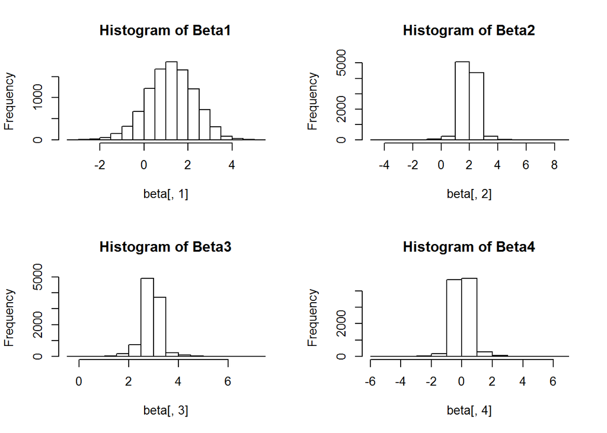

As shown in the histogram, the values of Beta1 is maily less than 5. Beta2 is maily located between 0 and 5. Beta3 is mainly located between 2 and 4. Beta4 is mainly located between -1 and 1.

```r
set.seed(12345)
y <- rnorm(n = 1e+06, mean = 1, sd = 1)
library(pander)

#################### Loop Method###############
t_lo <-
    system.time({
    mean_y <- mean(y)
    sum_difa <- 0
    for (i in 1:length(y)){
        sum_difa <- sum_difa + (y[i] - mean_y)^2
    }
})
Loop_Method <- c(t_lo[1:3], sum_difa)

#################### Vector Method###########
t_vec<-
    system.time({
  mean_y <- mean(y)
  diff_y <- y - mean_y
  sum_difb <- as.numeric(t(diff_y) %*% diff_y)
})
Vector_Method <- c(t_vec[1:3], sum_difb)

################ Dopar Method##############
library(foreach)
library(doParallel)
cl <- makeCluster(2)
registerDoParallel(cl)
t_dop <-
    system.time({
    mean_y <- mean(y)
    sum_difc <- foreach(1) %dopar% sum((y - mean_y)^2)
    })
stopCluster(cl)
Dopar_Method <- c(t_dop[1:3], sum_difc)

############### ParSapply Method###############
mean_y <- mean(y)
t_parsap <-
    system.time({
        c2 <- makeCluster(2)
        clusterExport(c2, "mean_y")
        sum_difd <- sum(parSapply(c2, y, function(y) (y-mean_y)^2))
    })
stopCluster(c2)
ParSapply_Method <- c(t_parsap[1:3], sum_difd)

#################### Summary####################
time_1 <- rbind(Loop_Method, Vector_Method, Dopar_Method, ParSapply_Method)
colnames(time_1)[4] <- c("Sum of Squares")
pander(time_1, caption = "Time for Different Methods")

################## Create data point################
set.seed(1256)
theta <- as.matrix(c(1,2),nrow=2)
X <- cbind(1,rep(1:10,10))
h <- X%*%theta+rnorm(100,0,0.2)
m <- length(h)
cl <- makeCluster(2)
registerDoParallel(cl)

############### Gradient descent################
GD_time <-
system.time({
dif1 <- 1
dif2 <- 1
alpha <- 0.001
ttheta <-
  foreach (i = 1:10, .combine = "cbind") %dopar% {
  tolerance <- 10^(1-i)
  while(dif1 > tolerance | dif2 > tolerance){
  grad_0 <- (1/m) * sum(((X%*%theta) - h))
  grad_1 <- (1/m) * t(X[, 2]) %*% ((X%*%theta) - h)
  theta_0 <- theta[1] - alpha * grad_0
  theta_1 <- theta[2] - alpha * grad_1
  dif1 <- abs(theta_0 - theta[1])
  dif2 <- abs(theta_1 - theta[2])
  theta[1] <- theta_0
  theta[2] <- theta_1
  }

  return(c(tolerance, theta[1], theta[2]))
  }
})
theta <- t(ttheta)
colnames(theta) <- c("Tolerance", "theta1", "theta2")
stopCluster(cl)

################## Linear regression##############
Linear_Time <-
system.time({
  lm_h <- lm(h~0+X)
Linear_coef <- t(data.frame(lm_h$coefficients))
})

################## Summary###################
pander(rbind(GD_time, Linear_Time), caption = "Running time for GD and Linear Methods")
pander(theta, caption = "Coefficients of GD Method")
pander(Linear_coef, caption = "Coefficients of Linear Regression Methods")
set.seed(1267)
n <- 200
X <- 1/cbind(1, rt(n, df = 1), rt(n, df = 1), rt(n, df = 1))
beta <- c(1, 2, 3, 0)
Y <- X %*% beta + rnorm(100, sd = 3)
data <- cbind(X, Y)
Y <- data[, 5]
X1 <- data[, 1]
X2 <- data[, 2]
X3 <- data[, 3]
X4 <- data[, 4]
cl <- makeCluster(2)
registerDoParallel(cl)
beta <- matrix(NA, nrow = 10000, ncol = 4)
colnames(beta) <- c("Intercept", "X2", "X3", "X4")
tbeta <-
  foreach (b = 1:10000, .combine = data.frame) %dopar% {
    i <- sample(1:200, size = 10, replace = TRUE)
    y <- Y[i]
    x1 <- X1[i]
    x2 <- X2[i]
    x3 <- X3[i]
    x4 <- X4[i]
    lm(y~0+x1+x2+x3+x4)$coef
  }
beta <- t(tbeta)
stopCluster(cl)
library(pander)
pander(head(beta), caption = "Overview of Beta")
pander(summary(beta), caption = "Summary of Beta")
par(mfrow = c(2, 2))
hist(beta[, 1], main = "Histogram of Beta1")
hist(beta[, 2], main = "Histogram of Beta2")
hist(beta[, 3], main = "Histogram of Beta3")
hist(beta[, 4], main = "Histogram of Beta4")
```